# HW4_XianjieQue

2025-02-22

## 5.2

### 5.2 (a) What is the probability that the first bootstrap observation is not the jth observation from the original sample? Justify your answer.

The probability that the first bootstrap observation is not the jth observation is:

$1 - 1/n$ = $\frac{n-1}{n}$

Since all observations have the same chance of being chosen, the probability is the number of favorable cases dividing by the total number of possible cases. That is, n−1 observations other than the jth observation dividing by the n total observations.

### 5.2 (b) What is the probability that the second bootstrap observation is not the jth observation from the original sample?

The probability that the second bootstrap observation is not the jth observation is also:

$\frac{n-1}{n}$

Since we sample with replacement, the justification is the same as in (a).

### 5.2 (c) Argue that the probability that the jth observation is not in the bootstrap sample is (1 - 1/n)^n.

We already proved that the probability of not taking the jth observation is $\frac{n-1}{n}$ = $1 - 1/n$. Now, we want to the probability of not having the jth observation in the whole bootstrap sample.

Since choosing observations are independent, we need only multiply the probabilities of all events. So the probability of not taking the jth observation is $(1 - 1/n)^n$.

### 5.2 (d) When n = 5, what is the probability that the jth observation is in the bootstrap sample?

Having the jth observation in the bootstrap sample is the complementary event of not having the jth observation in any of the bootstrap samples.

Using the result in (c) and n=5, P ≈ 0.67232

```r
n <- 5
1 - (1 - 1/n)^n
```

```
## [1] 0.67232
```

### 5.2 (e) When n = 100, what is the probability that the jth observation is in the bootstrap sample?

It’s similar to (d) and we only need to change n=100. P ≈ 0.6339677

```r
n <- 100
1 - (1 - 1/n)^n
```

```
## [1] 0.6339677
```

### 5.2 (f) When n = 10,000, what is the probability that the jth observa- tion is in the bootstrap sample?

It’s similar to (f) and we only need to change n=10000. P ≈ 0.632139

```r
n <- 10000
1 - (1 - 1/n)^n
```

```
## [1] 0.632139
```

### 5.2 (g) Create a plot and comment on what you observe.

1 - (1/100000)^100000 ≈ 0.6321

When n increases, the probability rapidly approaches 0.6321 and the graph is basically a straight line over the range [0,100000].

To show the change more transparently, I also did a log transformation on the right graph.

Note that
$$e^x = \lim_{x \to \inf}
\left(1 + \frac{x}{n}\right)^n,$$

so with $x = -1$, we can see that our limit is $1 - e^{-1} = 1 - 1/e$.

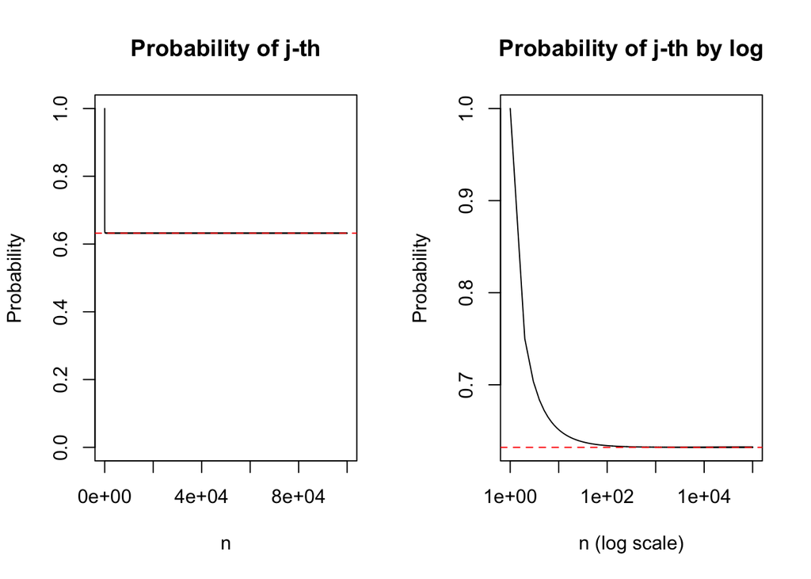

```r
x <- sapply(1:100000, function(n) 1 - (1 - 1 / n)^n)

par(mfrow=c(1,2))
plot(x, type = "l", pch = 20,
     xlab = "n",
     ylab = "Probability",
     ylim = c(0, 1),
     main = "Probability of j-th")
abline(h = 0.6321, col = "red", lty = 2)

# log transformation
plot(x, log = "x", type = "l", pch = 20,
     xlab = "n (log scale)",
     ylab = "Probability",
     main = "Probability of j-th by log")
abline(h = 0.6321, col = "red", lty = 2)
```

### 5.2 (h) We will now investigate numerically the probability that a bootstrap sample of size n = 100 contains the jth observation. Here j = 4. We repeatedly create bootstrap samples, and each time we record whether or not the fourth observation is contained in the bootstrap sample.

First, the mean of ‘store’ here is the proportion of the 10,000 entries in ‘store’ that had value TRUE = 1. It also means the proportion of the 10,000 entries which contains the 4th observation. So we can consider it as the probability that a bootstrap sample of size n = 100 contains the jth observation.

From the result in (e), the probability of including the 4th observation is $1 - (1 - 1/100)^{100}$ = 0.6339677

Each time I run the code, I will get a different mean, but the mean is always close to the real probability, 0.63

```r
store <- rep(NA, 10000)
for(i in 1:10000){
  store[i] <- sum(sample(1:100, rep=TRUE) == 4) > 0
  }
mean(store)
```

```
## [1] 0.6285
```

## 5.5

### 5.5 (a)

```r
# install.packages("ISLR2")
library(ISLR2)

str(Default)
```

```
## 'data.frame':    10000 obs. of  4 variables:
##  $ default: Factor w/ 2 levels "No","Yes": 1 1 1 1 1 1 1 1 1 1 ...
##  $ student: Factor w/ 2 levels "No","Yes": 1 2 1 1 1 2 1 2 1 1 ...
##  $ balance: num  730 817 1074 529 786 ...
##  $ income : num  44362 12106 31767 35704 38463 ...
```

```r
model_5_a <- glm(default ~ income + balance, data = Default, family = "binomial")
summary(model_5_a)
```

```
##
## Call:
## glm(formula = default ~ income + balance, family = "binomial",
##     data = Default)
##
## Coefficients:
##               Estimate Std. Error z value Pr(>|z|)
## (Intercept) -1.154e+01  4.348e-01 -26.545  < 2e-16 ***
## income       2.081e-05  4.985e-06   4.174 2.99e-05 ***
## balance      5.647e-03  2.274e-04  24.836  < 2e-16 ***
## ---
## Signif. codes:  0 '***' 0.001 '**' 0.01 '*' 0.05 '.' 0.1 ' ' 1
##
## (Dispersion parameter for binomial family taken to be 1)
##
##     Null deviance: 2920.6  on 9999  degrees of freedom
## Residual deviance: 1579.0  on 9997  degrees of freedom
## AIC: 1585
##
## Number of Fisher Scoring iterations: 8
```

### 5.5 (b)

The mean of test error is 2.56%

```r
# i. Split the sample set into a training set and a validation set.

# I choose 50% observations for training set.
set.seed(4)
train <- sample(10000, 5000)

# ii. Fit a multiple logistic regression model using only the training observations.

model_5_b <- glm(default ~ income + balance,
                 data = Default, subset = train,
                 family = "binomial")
summary(model_5_b)
```

```
##
## Call:
## glm(formula = default ~ income + balance, family = "binomial",
##     data = Default, subset = train)
##
## Coefficients:
##               Estimate Std. Error z value Pr(>|z|)
## (Intercept) -1.135e+01  6.096e-01 -18.613   <2e-16 ***
## income       9.504e-06  7.000e-06   1.358    0.175
## balance      5.772e-03  3.281e-04  17.591   <2e-16 ***
## ---
## Signif. codes:  0 '***' 0.001 '**' 0.01 '*' 0.05 '.' 0.1 ' ' 1
##
## (Dispersion parameter for binomial family taken to be 1)
##
##     Null deviance: 1477.13  on 4999  degrees of freedom
## Residual deviance:  792.65  on 4997  degrees of freedom
## AIC: 798.65
##
## Number of Fisher Scoring iterations: 8
```

```r
# iii. Obtain a prediction

pred_valid_b <- ifelse(predict(model_5_b, newdata = Default[-train, ],
                             type = "response") > 0.5, "Yes", "No")
pred_valid_b <- factor(pred_valid_b)
summary(pred_valid_b)
```

```
##   No  Yes
## 4922   78
```

```r
# iv. Compute the validation set error

mean(Default[-train, ]$default != pred_valid_b)
```

```
## [1] 0.0256
```

```r
# So the mean of test error is 2.56%
```

### 5.5 (c)

There is some variation, and it depends on the samples allocated to training sets, as I expected.

Compared to the mean of test error in (b): 0.0256, these values are very close.

```r
# Repeat the process in (b) three times
result_c <- c()

set.seed(4)

for (i in 1:3) {
  train <- sample(10000, 5000)

  model_5_c <- glm(default ~ income + balance,
                   data = Default, subset = train,
                   family = "binomial")
  pred_valid_c <- ifelse(predict(model_5_b, newdata = Default[-train, ],
                                 type = "response") > 0.5, "Yes", "No")
  pred_valid_c <- factor(pred_valid_c)
  result_c[i] <- mean(Default[-train, ]$default != pred_valid_c)
}

result_c
```

```
## [1] 0.0256 0.0274 0.0252
```

```r
mean(result_c)
```

```
## [1] 0.02606667
```

### 5.5 (d)

The new mean of test error is 0.0262

It’s larger than the result in (b). Compared to three results in (c), it’s only smaller than one of the three results.

So it can be concluded that including “student” does not reduce the test error rate, at least does not seem to make a substantial improvement to the test error.

```r
set.seed(4)
train <- sample(10000, 5000)
model_5_d <- glm(default ~ income + balance + student,
                 data = Default, subset = train,
                 family = "binomial")
summary(model_5_d)
```

```
##
## Call:
## glm(formula = default ~ income + balance + student, family = "binomial",
##     data = Default, subset = train)
##
## Coefficients:
##               Estimate Std. Error z value Pr(>|z|)
## (Intercept) -1.040e+01  6.773e-01 -15.358  < 2e-16 ***
## income      -1.704e-05  1.145e-05  -1.488  0.13683
## balance      5.932e-03  3.382e-04  17.542  < 2e-16 ***
## studentYes  -9.629e-01  3.242e-01  -2.970  0.00298 **
## ---
## Signif. codes:  0 '***' 0.001 '**' 0.01 '*' 0.05 '.' 0.1 ' ' 1
##
## (Dispersion parameter for binomial family taken to be 1)
##
##     Null deviance: 1477.13  on 4999  degrees of freedom
## Residual deviance:  783.85  on 4996  degrees of freedom
## AIC: 791.85
##
## Number of Fisher Scoring iterations: 8
```

```r
pred_valid_d <- ifelse(predict(model_5_d, newdata = Default[-train, ],
                             type = "response") > 0.5, "Yes", "No")
pred_valid_d <- factor(pred_valid_d)
summary(pred_valid_d)
```

```
##   No  Yes
## 4927   73
```

```r
mean(Default[-train, ]$default != pred_valid_d)
```

```
## [1] 0.0262
```

## 5.9

### 5.9 (a)

$\hat\mu$ is 22.53281

```r
str(Boston)
```

```
## 'data.frame':    506 obs. of  13 variables:
##  $ crim   : num  0.00632 0.02731 0.02729 0.03237 0.06905 ...
##  $ zn     : num  18 0 0 0 0 0 12.5 12.5 12.5 12.5 ...
##  $ indus  : num  2.31 7.07 7.07 2.18 2.18 2.18 7.87 7.87 7.87 7.87 ...
##  $ chas   : int  0 0 0 0 0 0 0 0 0 0 ...
##  $ nox    : num  0.538 0.469 0.469 0.458 0.458 0.458 0.524 0.524 0.524 0.524 ...
##  $ rm     : num  6.58 6.42 7.18 7 7.15 ...
##  $ age    : num  65.2 78.9 61.1 45.8 54.2 58.7 66.6 96.1 100 85.9 ...
##  $ dis    : num  4.09 4.97 4.97 6.06 6.06 ...
##  $ rad    : int  1 2 2 3 3 3 5 5 5 5 ...
##  $ tax    : num  296 242 242 222 222 222 311 311 311 311 ...
##  $ ptratio: num  15.3 17.8 17.8 18.7 18.7 18.7 15.2 15.2 15.2 15.2 ...
##  $ lstat  : num  4.98 9.14 4.03 2.94 5.33 ...
##  $ medv   : num  24 21.6 34.7 33.4 36.2 28.7 22.9 27.1 16.5 18.9 ...
```

```r
mean(Boston$medv)
```

```
## [1] 22.53281
```

### 5.9 (b)

The standard error of $\hat\mu$ is 0.4088611

```r
sd(Boston$medv) / sqrt(length(Boston$medv))
```

```
## [1] 0.4088611
```

### 5.9 (c)

The standard error estimated by using bootstrap is 0.4087221

Although not identical, the estimate is the same to 3dp: 0.4087 vs 0.4089. They are very close.

```r
library(boot)
boot.fn = function(vector, index)
  + mean(vector[index])
set.seed(4)
boot_mean <- boot(Boston$medv, boot.fn, 10000)
boot_mean
```

```
##
## ORDINARY NONPARAMETRIC BOOTSTRAP
##
##
## Call:
## boot(data = Boston$medv, statistic = boot.fn, R = 10000)
##
##
## Bootstrap Statistics :
##     original       bias    std. error
## t1* 22.53281 -0.001237767   0.4087221
```

### 5.9 (d)

The bootstrap 95% confidence interval is: [21.7154, 23.3503]

In One Sample t-test, 95% confidence interval is: [21.72953, 23.33608]

```r
# calculate the bootstrap 95% confidence interval
boot_mean_SE <- sd(boot_mean$t)
round(c(mean(Boston$medv) - 2*boot_mean_SE, mean(Boston$medv) + 2*boot_mean_SE), 4)
```

```
## [1] 21.7154 23.3503
```

```r
# using t.test(Boston$medv)
t.test(Boston$medv)
```

```
##
##  One Sample t-test
##
## data:  Boston$medv
## t = 55.111, df = 505, p-value < 2.2e-16
## alternative hypothesis: true mean is not equal to 0
## 95 percent confidence interval:
##  21.72953 23.33608
## sample estimates:
## mean of x
##  22.53281
```

### 5.9 (e)

The estimate of population median is the sample median: 21.2

```r
median(Boston$medv)
```

```
## [1] 21.2
```

### 5.9 (f)

The standard error estimated by using bootstrap is 0.3768153

The standard error of median is quite small relative to the estimate, even smaller than the standard error of mean: 0.4087221.

Similarly, the standard error of mean is quite small relative to the estimate.

```r
boot.fn = function(vector, index)
  + median(vector[index])
set.seed(4)
boot_median <- boot(Boston$medv, boot.fn, 10000)
boot_median
```

```
##
## ORDINARY NONPARAMETRIC BOOTSTRAP
##
##
## Call:
## boot(data = Boston$medv, statistic = boot.fn, R = 10000)
##
##
## Bootstrap Statistics :
##     original    bias    std. error
## t1*     21.2 -0.014255   0.3768153
```

### 5.9 (g)

The estimated population 10th Percentile is 12.75

```r
quantile(Boston$medv, 0.1)
```

```
##   10%
## 12.75
```

### 5.9 (h)

The standard error estimated by using bootstrap is 0.500903

The standard error of 10th Percentile is slightly larger relative to the estimate, also larger than the standard error of mean and median.

But it’s still small, so we can be confident about the value of the 10th percentile.

```r
boot.fn = function(vector, index)
  + quantile(vector[index], 0.1)
set.seed(4)
boot_quantile <- boot(Boston$medv, boot.fn, 10000)
boot_quantile
```

```
##
## ORDINARY NONPARAMETRIC BOOTSTRAP
##
##
## Call:
## boot(data = Boston$medv, statistic = boot.fn, R = 10000)
##
##
## Bootstrap Statistics :
##     original   bias    std. error
## t1*    12.75 0.008455    0.500903
```

## Additional Problem on Clustered bootstrap

```r
# generate clustered data
set.seed(4)

n_cluster <- 100
n_individual <- 5

ID <- rep(1:n_cluster, each = n_individual)

a <- rnorm(n_cluster, mean = 0, sd = 1)
a_i <- rep(a, each = n_individual)

x_ij <- rbinom(n_cluster * n_individual, size = 1, prob = 0.5)

e_ij <- rnorm(n_cluster * n_individual, mean = 0, sd = 1)

y_ij <- a_i + 0.5 * x_ij + e_ij

ori_data <- data.frame(ID, x_ij, y_ij)

# generate clustered bootstrap samples
clustered_boot <- sample(1:n_cluster, size = n_cluster, replace = TRUE)
boot_data <- do.call(rbind, lapply(1:n_cluster, function(new_id) {
  old_id <- clustered_boot[new_id]
  subset <- ori_data[ori_data$ID == old_id, ]
  subset$ID <- new_id
  return(subset)
}))

head(boot_data)
```

```
##     ID x_ij       y_ij
## 496  1    1  1.7453221
## 497  1    1 -0.5379045
## 498  1    0 -0.2050022
## 499  1    0 -2.1099935
## 500  1    0 -1.5445689
## 286  2    1  2.3584494
```

## 13.4

### (a) Controlling Type I Error at α = 0.05

If we control the Type I error for each individual hypothesis at α=0.05, we reject any null hypothesis where p<0.05

From the given p-values in Table 13.4, we reject H01, H02, HO3, H08, H09, H10

```r
pvalue <- c(0.0011, 0.031, 0.017, 0.32, 0.11, 0.90, 0.07, 0.006, 0.004, 0.0009)
names(pvalue) <- paste0("H", sprintf("%02d", 1:10))

names(which(pvalue < 0.05))
```

```
## [1] "H01" "H02" "H03" "H08" "H09" "H10"
```

### (b) Controlling FWER at α = 0.05

To control FWER, we apply Bonferroni correction: α’= α/m = 0.05/10 = 0.005

We reject null hypotheses where p<0.005.

From the given p-values, we reject H01, H09, H10

```r
names(which(pvalue < 0.005))
```

```
## [1] "H01" "H09" "H10"
```

### (c) Controlling FDR at q=0.05

We apply the Benjamini-Hochberg (BH) procedure, which sorts the p-values in ascending order and finds the largest k such that: p <= k/m * 0.05

H10 = 0.0009 < 0.005

H01 = 0.0011 < 0.01

H09 = 0.004 < 0.015

H08 = 0.006 < 0.02

H03 = 0.017 < 0.025

H02 = 0.031 > 0.03

H07 = 0.07 > 0.035

H04 = 0.32 > 0.04

H05 = 0.11 > 0.045

H06 = 0.90 > 0.05

So, we reject H01, H03, H08, H09, H10

I also use R function to compute and get the result.

```r
names(which(p.adjust(pvalue, "fdr") < 0.05))
```

```
## [1] "H01" "H03" "H08" "H09" "H10"
```

### (d) Controlling FDR at q=0.2

Using the Benjamini-Hochberg method again with q=0.2:

H10 = 0.0009 < 0.02

H01 = 0.0011 < 0.04

H09 = 0.004 < 0.06

H08 = 0.006 < 0.08

H03 = 0.017 < 0.1

H02 = 0.031 < 0.12

H07 = 0.07 < 0.14

H04 = 0.32 > 0.16

H05 = 0.11 < 0.18

H06 = 0.90 > 0.2

So, we reject all except H04 and H06, which is: H01, H02, H03, H05, H07, H08, H09, H10

I also use R function to compute and get the result.

```r
names(which(p.adjust(pvalue, "fdr") < 0.2))
```

```
## [1] "H01" "H02" "H03" "H05" "H07" "H08" "H09" "H10"
```

### (e)

q = 0.2 means 20% rejections to be false positives.

Since in (d) we reject 8 hypotheses, 0.2 × 8 = 1.6

So approximately 1 to 2 of the rejected hypotheses are likely false positives.

And 1.6 ≈ 2, so I think 2 false positives are more likely.

## 13.7

### (a) Compute the p-values for each quantitative variable

Excluding “Sales”, the “Carseats” dataset includes these quantitative variables:

CompPrice, Income, Advertising, Population, Price, Age, Education

```r
library(ISLR2)
head(Carseats)
```

```
##   Sales CompPrice Income Advertising Population Price ShelveLoc Age Education
## 1  9.50       138     73          11        276   120       Bad  42        17
## 2 11.22       111     48          16        260    83      Good  65        10
## 3 10.06       113     35          10        269    80    Medium  59        12
## 4  7.40       117    100           4        466    97    Medium  55        14
## 5  4.15       141     64           3        340   128       Bad  38        13
## 6 10.81       124    113          13        501    72       Bad  78        16
##   Urban  US
## 1   Yes Yes
## 2   Yes Yes
## 3   Yes Yes
## 4   Yes Yes
## 5   Yes  No
## 6    No Yes
```

```r
str(Carseats)
```

```
## 'data.frame':    400 obs. of  11 variables:
##  $ Sales      : num  9.5 11.22 10.06 7.4 4.15 ...
##  $ CompPrice  : num  138 111 113 117 141 124 115 136 132 132 ...
##  $ Income     : num  73 48 35 100 64 113 105 81 110 113 ...
##  $ Advertising: num  11 16 10 4 3 13 0 15 0 0 ...
##  $ Population : num  276 260 269 466 340 501 45 425 108 131 ...
##  $ Price      : num  120 83 80 97 128 72 108 120 124 124 ...
##  $ ShelveLoc  : Factor w/ 3 levels "Bad","Good","Medium": 1 2 3 3 1 1 3 2 3 3 ...
##  $ Age        : num  42 65 59 55 38 78 71 67 76 76 ...
##  $ Education  : num  17 10 12 14 13 16 15 10 10 17 ...
##  $ Urban      : Factor w/ 2 levels "No","Yes": 2 2 2 2 2 1 2 2 1 1 ...
##  $ US         : Factor w/ 2 levels "No","Yes": 2 2 2 2 1 2 1 2 1 2 ...
```

```r
quant_vars <- c("CompPrice", "Income", "Advertising", "Population", "Price", "Age", "Education")

# Compute p-values for each variable
p_values <- sapply(quant_vars, function(var) {
  model <- lm(Sales ~ Carseats[[var]], data = Carseats)
  summary(model)$coefficients[2,4]
})

p_values
```

```
##    CompPrice       Income  Advertising   Population        Price          Age
## 2.009398e-01 2.309670e-03 4.377677e-08 3.139816e-01 7.618187e-21 2.788950e-06
##    Education
## 2.999442e-01
```

### (b) Control Type I error at α=0.05

This means we reject the null hypothesis for variables where the p-value is less than 0.05.

They are: “Income”, “Advertising”, “Price”, “Age”

```r
names(which(p_values < 0.05))
```

```
## [1] "Income"      "Advertising" "Price"       "Age"
```

### (c) Control FWER at 0.05

To control the FWER, I used the Bonferroni correction, which adjusts the significance threshold as α(Bonferroni) = 0.05/m

And I reject the variables with a p-value below this adjusted threshold.

They are: “Income”, “Advertising”, “Price”, “Age”

```r
names(which(p_values < 0.05 / length(quant_vars)))
```

```
## [1] "Income"      "Advertising" "Price"       "Age"
```

### (d) Control FDR at 0.2

I reject the variables: “Income”, “Advertising”, “Price”, “Age”

```r
names(which(p.adjust(p_values, "fdr") < 0.2))
```

```
## [1] "Income"      "Advertising" "Price"       "Age"
```

## Additional Problem

### Let FDR=0.05. Suppose only 1% of 10,000 tests are truly significant.

### If we make 100 rejections, then α=?

Total hypotheses tested: 10,000

H0 false: 1% = 100

H0 true: 9,900

FDR = 0.05 = V/R

since R = 100, so V = 0.05×100 = 5

α = V / H0 true = 5/9900 ≈ 0.000505

### If we make 200 rejections, then α=?

since R = 200, so V = 0.05×200 = 10

α = V / H0 true = 10/9900 ≈ 0.00101

### Let α =0.01. Suppose only 1% of 10,000 tests are truly significant.

### If we make 100 rejections, then FDR=?

Total hypotheses tested: 10,000

H0 false: 1% = 100

H0 true: 9,900

Since α = 0.01, V = α × 9900 = 0.01 × 9900 = 99

Since we make 100 rejections, R = 100

FDR = V/R = 99/100 = 0.99

### If we make 200 rejections, then FDR=?

Since α = 0.01, V = α × 9900 = 0.01 × 9900 = 99

Since we make 200 rejections, R = 200

FDR = V/R = 99/200 = 0.495